# Time Series Analysis of Monthly Temperatures in Nottem

Sean Schilk

11/30/2025

This project will be the culmination of all the time series methods we have learned thus far. The data set that is used is Nottem, provided by R

It’s described as a time series object containing average air temperatures at Nottingham Castle in degrees Fahrenheit for 20 years.

Before we start we want to do 2 things. First, there are more than 200 observations, so we want to drop the oldest 40. Next, as it is monthly data, we want to hold up 12 observations for our test set. The rest of the data will be used to train the smoothing model.

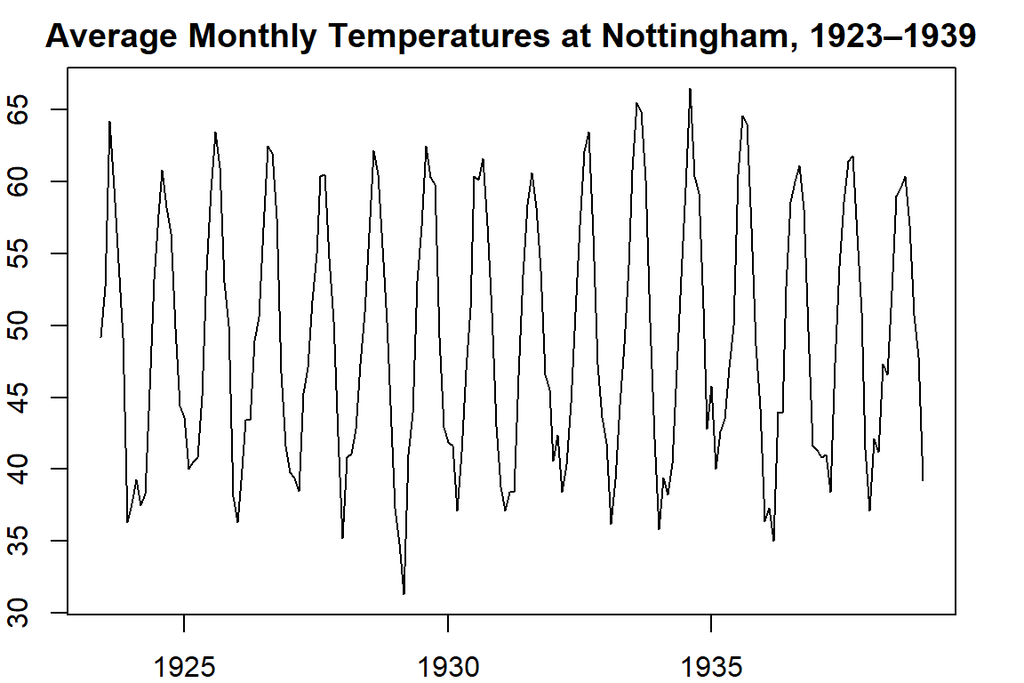

```r
#?nottem
data(nottem)
#200 MOST RECENT OBS
nottem <- tail(nottem, 200)

training = nottem[1:188]
testing = nottem[189:200]

nottem.ts = ts(training, frequency = 12, start = c(1923, 6))

par(mar=c(2,2,2,2))
plot(nottem.ts, main="Average Monthly Temperatures at Nottingham, 1923–1939", ylab="Monthly Temp", xlab="")
```

Next, we will fit three types of smoothing models: simple exponential model, Holt models (additive, with possible damped pattern), Holt-Winter’s models (additive and multiplicative seasonality with a possible damped pattern.)

```r
# Simple ETS, assumes no trend/seasonality ~ ETS(N,N,N)
# Good for stable series with no systematic pattern
fit1 = ses(nottem.ts, h=12) # h = holdout obs num

# Holt Linear: level + linear trend, No seasonality
# Forecasts continue increasing/decreasing indefinitely (no adjustment)
fit2 = holt(nottem.ts, initial="optimal", h=12)

# Holt Additive Damped : Level + linear trend, trend flattens (damps) over time
fit3 = holt(nottem.ts,damped=TRUE, h=12 )

# Holt Exponential: Holt Linear with multiplicative/exp trend growth
fit4 = holt(nottem.ts,exponential=TRUE, damped=TRUE, h =12) ## multiplicative damp

#Holt-Winters Additive: level, trend AND + seasonality
# Good when seasonal fluctuations are stable (e.g., ±5 degrees every year)
fit5 = hw(nottem.ts,h=12, seasonal="additive")              ## default h = 10

#6. Holt-Winters Exponential (Multiplicative Seasonality):
# Good when seasonality increases/decreases with overall level
fit6 = hw(nottem.ts,h=12, seasonal="multiplicative")

#7. Holt-Winters Additive Damped: same as +, but with damped trend
fit7 = hw(nottem.ts,h=12, seasonal="additive",damped=TRUE)

# 8. Holt-Winters Exponential Damped (your best model):
# Level + trend + multiplicative seasonality + damped trend
fit8 = hw(nottem.ts,h=12, seasonal="multiplicative",damped=TRUE)
```

```r
accuracy.table = round(rbind(accuracy(fit1), accuracy(fit2), accuracy(fit3), accuracy(fit4),
                             accuracy(fit5), accuracy(fit6), accuracy(fit7), accuracy(fit8)),4)
row.names(accuracy.table)=c("SES","Holt Linear","Holt Add. Damped", "Holt Exp. Damped",
                            "HW Add.","HW Exp.","HW Add. Damp", "HW Exp. Damp")
kable(accuracy.table, caption = "The accuracy measures of various exponential smoothing models
      based on the training data")
```

The accuracy measures of various exponential smoothing models based on the training data

|  | ME | RMSE | MAE | MPE | MAPE | MASE | ACF1 |
| --- | --- | --- | --- | --- | --- | --- | --- |
| SES | -0.0531 | 5.2784 | 4.4237 | -0.7301 | 9.2066 | 1.7100 | 0.4983 |
| Holt Linear | -0.1397 | 5.0079 | 4.0453 | 0.3789 | 8.5262 | 1.5637 | -0.0233 |
| Holt Add. Damped | -0.0546 | 4.9265 | 3.9583 | 0.1558 | 8.2892 | 1.5301 | 0.0333 |
| Holt Exp. Damped | -0.3153 | 5.2140 | 4.3513 | -0.8790 | 9.0357 | 1.6820 | 0.4065 |
| HW Add. | -0.0124 | 2.1737 | 1.7078 | -0.2493 | 3.7240 | 0.6602 | 0.1764 |
| HW Exp. | -0.1053 | 2.2443 | 1.7712 | -0.4819 | 3.8595 | 0.6847 | 0.2039 |
| HW Add. Damp | 0.0349 | 2.1466 | 1.6752 | -0.1506 | 3.6427 | 0.6475 | 0.1973 |
| HW Exp. Damp | 0.0524 | 2.1463 | 1.6668 | -0.1073 | 3.6034 | 0.6443 | 0.2132 |

The above table shows that the HW Exp. Damped seems to be the most appropriate.

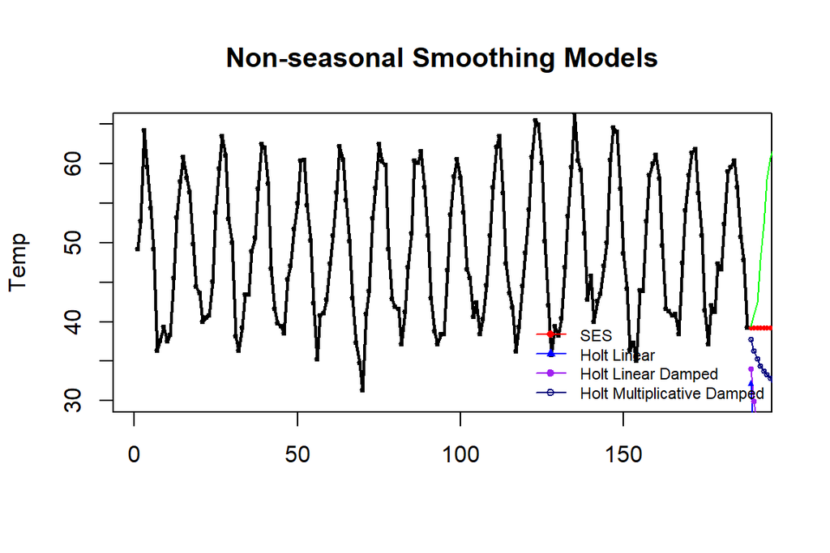

```r
###### plot the original data
pred.id = 189:200
plot(1:188, training, lwd=2,type="o", ylab="Temp", xlab="",
     xlim=c(1,188), ylim=c(30, 65), cex=0.3,
     main="Non-seasonal Smoothing Models")
lines(pred.id, fit1$mean, col="red")
lines(pred.id, fit2$mean, col="blue")
lines(pred.id, fit3$mean, col="purple")
lines(pred.id, fit4$mean, col="navy")
lines(pred.id, testing, col="green") # add testing data to see how well our forecast did visually
points(pred.id, fit1$mean, pch=16, col="red", cex = 0.5)
points(pred.id, fit2$mean, pch=17, col="blue", cex = 0.5)
points(pred.id, fit3$mean, pch=19, col="purple", cex = 0.5)
points(pred.id, fit4$mean, pch=21, col="navy", cex = 0.5)
lines(pred.id, testing, col="green")
#points(fit0, col="black", pch=1)
legend("bottomright", lty=1, col=c("red","blue","purple", "navy"),pch=c(16,17,19,21),
   c("SES","Holt Linear","Holt Linear Damped", "Holt Multiplicative Damped"),
   cex = 0.7, bty="n")
```

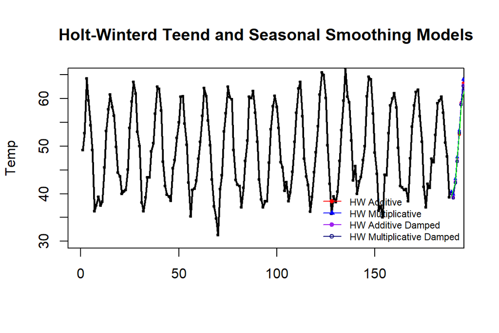

```r
###########
plot(1:188, training, lwd=2,type="o", ylab="Temp", xlab="",
     xlim=c(1,188), ylim=c(30, 65), cex=0.3,
     main="Holt-Winterd Teend and Seasonal Smoothing Models")
lines(pred.id, fit5$mean, col="red")
lines(pred.id, fit6$mean, col="blue")
lines(pred.id, fit7$mean, col="purple")
lines(pred.id, fit8$mean, col="navy")
lines(pred.id, testing, col="green")
points(pred.id, fit5$mean, pch=16, col="red", cex = 0.5)
points(pred.id, fit6$mean, pch=17, col="blue", cex = 0.5)
points(pred.id, fit7$mean, pch=19, col="purple", cex = 0.5)
points(pred.id, fit8$mean, pch=21, col="navy", cex = 0.5)
lines(pred.id, testing, col="green")
###
legend("bottomright", lty=1, col=c("red","blue","purple", "navy"),pch=c(16,17,19,21),
   c("HW Additive","HW Multiplicative","HW Additive Damped", "HW Multiplicative Damped"),
   cex = 0.7, bty="n")
```

```r
acc.fun = function(test.data, mod.obj){
  PE=100*(test.data-mod.obj$mean)/mod.obj$mean
  MAPE = mean(abs(PE))
  ###
  E=test.data-mod.obj$mean
  MSE=mean(E^2)
  ###
  accuracy.metric=c(MSE=MSE, MAPE=MAPE)
  accuracy.metric
}
```

```r
library(forecast)
pred.accuracy = rbind(SES =acc.fun(test.data=testing, mod.obj=fit1),
                      Holt.Add =acc.fun(test.data=testing, mod.obj=fit2),
                      Holt.Add.Damp =acc.fun(test.data=testing, mod.obj=fit3),
                      Holt.Exp =acc.fun(test.data=testing, mod.obj=fit4),
                      HW.Add =acc.fun(test.data=testing, mod.obj=fit5),
                      HW.Exp =acc.fun(test.data=testing, mod.obj=fit6),
                      HW.Add.Damp =acc.fun(test.data=testing, mod.obj=fit7),
                      HW.Exp.Damp =acc.fun(test.data=testing, mod.obj=fit8))
kable(pred.accuracy, caption="The accuracy measures of various exponential smoothing models
      based on the testing data")
```

The accuracy measures of various exponential smoothing models based on the testing data

|  | MSE | MAPE |
| --- | --- | --- |
| SES | 171.798295 | 26.591975 |
| Holt.Add | 4375.688706 | 569.355914 |
| Holt.Add.Damp | 935.398254 | 151.009318 |
| Holt.Exp | 331.608624 | 47.558157 |
| HW.Add | 3.425633 | 2.928948 |
| HW.Exp | 3.786411 | 3.124747 |
| HW.Add.Damp | 3.179088 | 2.956838 |
| HW.Exp.Damp | 3.019612 | 2.810868 |

We can see from the above accuracy table that HW’s exponential dampened trend model with multiplicative seasonality (fit8) is the best of the eight smoothing models. This is consistent with the patterns in the original serial plot.

In the previous analysis, we train the model with the training data and identify the best model using both training and testing data. In real-forecast, we need to refit the model at the very end using the entire data to update the smoothing parameters in the final working model.

```r
final.model = hw(nottem,h=12, seasonal="multiplicative",damped=TRUE)
# point here is that we are refitting using all 200 obs
smoothing.parameter = final.model$model$par[1:4]
kable(smoothing.parameter, caption="Estimated values of the smoothing parameters in
      Holt-Winters exponential trend with multiplicative seasonality")
```

Estimated values of the smoothing parameters in Holt-Winters exponential trend with multiplicative seasonality

|  | x |
| --- | --- |
| alpha | 0.0001392 |
| beta | 0.0001115 |
| gamma | 0.0001023 |
| phi | 0.9782359 |

In summary, the updated values of the three smoothing parameters in the Holt-Winters exponential dampened trend and with multiplicative seasonality using the entire data are given in the above table.

alpha controls how quickly the level updates beta controls how quickly the trend updates gamma controls how quickly the seasonal pattern updates phi controls how strongly the trend is damped

# 1 Conclusion

We did model selection on the training data, then found the best model by checking accuracy against the testing data, then refit our final chosen model using the total dataset.